# La technologie 5G, quel impact pour la numérisation de la société et l’environnement ?

Valentine Gripois-Sabino

07 February 2023

# 1 .L’histoire de la 5G

Depuis l’apparition de la première génération de technologie sans fil cellulaire (1G) en 1980, les réseaux n’ont cessé de se développer pour faciliter la transmission des données. Ainsi, 40 ans plus tard, on accède au cinquième standard des réseaux mobiles de télécommunications. La 1G permettait seulement de passer des appels téléphoniques, tandis que la 2G a amené l’apparition des SMS et MMS. L’accès aux données mobiles liées à la navigation sur internet a vu le jour avec la 3G et la 4G a permis de généraliser l’usage de la mobilité connectée. Au fil du temps, le débit offert par ces générations mobiles n’a fait qu’augmenter. (Routeur-5G, 2019)

Voici un aperçu de l’évolution du débit des différentes générations mobiles :

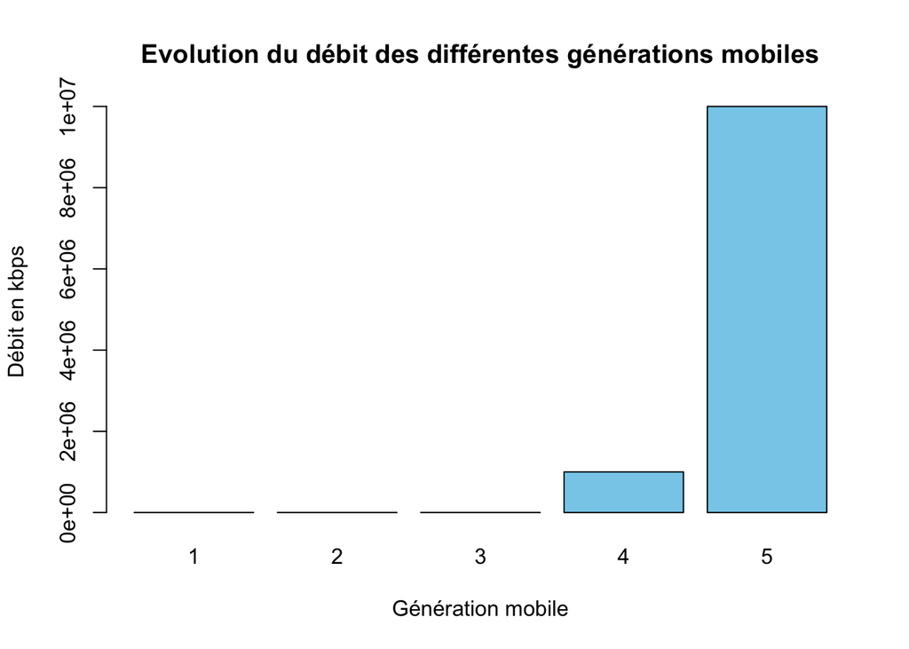

```r
debit <- read.table("../Rapport Individuel/debit.txt",
                   header=TRUE, sep="\t")

debitbis <-as.numeric(debit[,2])

barplot(debitbis, xlab = "Génération mobile", ylab = "Débit en kbps", main="Evolution du débit des différentes générations mobiles", col="skyblue",names.arg = debit[,1])
```

On constate que le débit présent pour la 5G est à peine comparable aux premières générations. Les premiers débits sont tellement faibles par rapport aux dernières générations mobiles, qu’ils n’apparaissent pas sur le graphique. En effet, on est passés de 2 kpbs pour la 1G à 10 000 000 kbps pour la 5G, soit 10 Gbps !

Tandis que le monde du numérique se développe, les innovations qui voient le jour requièrent davantage de débit, de performance, de bonne transmission, etc.

La 5G est une technologie récente, en plein essor depuis 2020. Elle provient d’un projet lancé par l’Union Européenne en 2013, visant à éviter la saturation du réseau 4G. Au cours de son développement, la Commission européenne a signé des accords avec de nombreux pays pour faciliter les échanges concernant l’innovation et le développement de nouvelles technologies. Une fois la technologie mise en place, les enchères pour les bandes de fréquences de 3400 MHz à 3800 MHz ont commencé. Ces enchères permettent aux différents opérateurs d’acquérir un certain nombre de bande de fréquence et ainsi être présent en force ou en faiblesse sur le réseau.

Ainsi, Orange a pu obtenir des bandes de fréquence sur **900** communes, Bouygues sur **3000**, SFR sur **3600** et Free sur **10 000** communes !

En 2020, les tous premiers forfaits incluant la 5G sont lancés chez les principaux opérateurs. Pour donner une idée de ce qui la différencie du réseau 4G : sa vitesse est améliorée, elle dispose d’une faible latence et est peu consommatrice en électricité.

Néanmoins, la 5G a fait l’objet de nombreuses critiques et théories du complot. En effet, elle a été accusée de d’avoir un impact sur la santé. Des élus se sont donc opposés à son déploiement mais des études sont venues attester que la 5G n’avait pas d’impact néfaste sur la santé et que les ondes émises respectaient les normes.

Sa structure a aussi été développée pour répondre aux besoins de tous les IoT (Internet des objets) qui voient de plus en plus le jour. La 5G pourra « apporter le niveau de performance nécessaire à un développement massif d’objets connectés » (Group, [sans date]). Par conséquent, elle permettra de faciliter la numérisation de la société, notamment avec les nouvelles technologies telles que les véhicules autonomes, la connectivité des machines dans les industries, la réalité virtuelle, etc.

# 2 .Impact sur la numérisation de la société

La technologie 5G voit grand et souhaite étendre son champ d’application à d’autres secteurs que les opérateurs mobiles et les communications grand public. En effet, son objectif est de gérer d’une meilleure manière les technologies de la santé, des médias, de l’énergie, de l’industrie ou du transport. Par exemple, des progrès pourront voir le jour concernant des robots pour des chirurgies spécialisées, les voitures connectées, des opérations à distance en temps réel ou encore des capteurs connectés pour l’amélioration des processus industriels. Bien que le monde du futur soit déjà en pleine expansion, la 5G permettra d’accélérer ses processus et les améliorer.

Ce nouveau développement de réseau devrait offrir devrait créer plus d’1 million d’emplois selon Orange. Cette technologie est de même intéressante pour les entreprises puisque qu’elle facilitera le travail, le développement à distance, innovation sur les offres produits et services.

Néanmoins la 5G présente des doutes pour certains dirigeants d’entreprise qui redoutent davantage de cyberattaque. En effet, ils considèrent qu’elle détient des failles de sécurité et qu’elle est peut-être plus vulnérable à cause du nombre de variété de terminaux, d’équipements connectés et la multiplication du nombre de point d’accès.

# 3 .Impact environnemental du numérique

Les réseaux soient en constante transition, par conséquent, de plus en plus de questions se soulèvent quant à l’impact que peut avoir la 5G sur l’environnement du numérique. Encore une fois, ce nouveau déploiement de réseau à du faire face à de nouvelles critiques et interrogations par la population. Il faut prendre en compte que le déploiement de la 5G implique d’avoir un téléphone permettant d’utiliser la 5G (donc potentiellement, beaucoup de renouvellement d’appareil) ainsi que la construction de nouvelles antennes. Ces changements nécessitent des énergies non renouvelables telles que les énergies fossiles, ou bien l’extraction de minerais (pour des composantes des téléphones portables par exemple) et globalement, cela aura un impact négatif sur l’environnement (réchauffement climatique et production gaz à effet de serre).

Une étude a donc été menée par l’Arcep (Autorité de régulation des communications électroniques, des postes et de la distribution de la presse) pour comparer la consommation énergétique du déploiement en cours de la 5G sur les bandes (3,5 GHz) et le déploiement de la 4G.

Les volumes de données numériques n’ont cessé d’augmenter ces dernières années. Cependant, la 4G est plus consommatrice en énergie que la 5G. En effet, cette dernière peut traiter plus de données de manière simultanée et plus rapidement, ce qui implique une durée de fonctionnement limitée et donc une utilisation d’énergie limitée également.

D’après Orange, « La 5G et la contribution du numérique pourraient donc, dans les années à venir, se révéler être nos meilleurs alliés pour réduire les émissions de gaz à effet de serre, action essentielle dans la lutte contre le réchauffement climatique. ». Elle devrait permettre d’éviter le rejet de 33 millions de tonnes d’équivalent CO2 d’ici 2030 d’après une étude l’OMDIA.

# .*Bibliographie :*

GROUP, Thales, [sans date]. *Qu’est-ce que la 5G ?* [en ligne]. [Consulté le 3 février 2023]. Disponible à l'adresse : https://www.thalesgroup.com/fr/europe/france/dis/mobile/inspiration/5g

ROUTEUR-5G, 2019. *Quelle est l’histoire de la 5G ?* [en ligne]. 2019. [Consulté le 3 février 2023]. Disponible à l'adresse : https://routeur-5g.fr/smartphone-5g/quelle-histoire-5g/